# SKAT_wecare_only

started: Alexey Larionov, 27Mar2017  
last updated: Alexey Larionov, 20Apr2017

# Summary

SKAT cbc vs ubc, wecare only

Efficient Resampling (ER) is used because this is the most accurate (?) method for  
P-assessment from small counts in SKAT package (Lee et al Biostatistics 2016)  
However, Efficient Resampling may become computationally heavy for larger number of samples…

~5hrs for method.bin = “ER” (for is.accurate, MAP and adjusted QQPlot)  
~10 min with default method.bin (= “Hybrid”; using ER only for counts < 20?)

is.accurate and MAP are only valid for for resampling methods (ER or ER.A)

# start_section

```r
# Start time
Sys.time()
```

```
## [1] "2017-04-20 19:48:50 BST"
```

```r
# Folders
#/analysis/mtgroup_share
#/scratch/medgen
setwd("/analysis/mtgroup_share/scripts/wecare_stat_04.17/scripts/wecare_only")
source_data_folder <- "/analysis/mtgroup_share/scripts/wecare_stat_04.17/source_data"
interim_data_folder <- "/analysis/mtgroup_share/scripts/wecare_stat_04.17/scripts/wecare_only/interim_data"
results_folder <- "/analysis/mtgroup_share/scripts/wecare_stat_04.17/scripts/wecare_only/results"

# Libraries
library(SKAT)
```

# load_data

```r
load(paste(interim_data_folder, "s08_filter_by_variant_effect_wecare_only.RData", sep="/"))
```

# check_data

```r
dim(genotypes.mx)
```

```
## [1] 18551   478
```

```r
class(genotypes.mx)
```

```
## [1] "matrix"
```

```r
genotypes.mx[1:5,1:5]
```

```
##              P1_A01 P1_A02 P1_A03 P1_A04 P1_A05
## Var000000026      0     NA      0      0      0
## Var000000029      0      0      0      0      0
## Var000000031      0      0      0      0      0
## Var000000053      0      0      0      0     NA
## Var000000064      0      0      0      0     NA
```

```r
dim(genes.df)
```

```
## [1] 9117    2
```

```r
class(genes.df)
```

```
## [1] "data.frame"
```

```r
genes.df[1:5,]
```

```
##         genes counts_per_gene
## NOC2L   NOC2L               4
## KLHL17 KLHL17               2
## AGRN     AGRN              36
## TTLL10 TTLL10               2
## PUSL1   PUSL1               1
```

```r
dim(kgen.df)
```

```
## [1] 18551     9
```

```r
colnames(kgen.df)
```

```
## [1] "SplitVarID"  "kgen.AC"     "kgen.AN"     "kgen.AF"     "kgen.AFR_AF"
## [6] "kgen.AMR_AF" "kgen.EAS_AF" "kgen.EUR_AF" "kgen.SAS_AF"
```

```r
kgen.df[1:5,1:5]
```

```
##                SplitVarID kgen.AC kgen.AN     kgen.AF kgen.AFR_AF
## Var000000026 Var000000026      NA      NA          NA          NA
## Var000000029 Var000000029       1    5008 0.000199681           0
## Var000000031 Var000000031       1    5008 0.000199681           0
## Var000000053 Var000000053      NA      NA          NA          NA
## Var000000064 Var000000064      NA      NA          NA          NA
```

```r
dim(exac.df)
```

```
## [1] 18551    48
```

```r
colnames(exac.df)
```

```
##  [1] "SplitVarID"              "exac_non_TCGA.AF"
##  [3] "exac_non_TCGA.AC"        "exac_non_TCGA.AN"
##  [5] "exac_non_TCGA.AC_FEMALE" "exac_non_TCGA.AN_FEMALE"
##  [7] "exac_non_TCGA.AC_MALE"   "exac_non_TCGA.AN_MALE"
##  [9] "exac_non_TCGA.AC_Adj"    "exac_non_TCGA.AN_Adj"
## [11] "exac_non_TCGA.AC_Hom"    "exac_non_TCGA.AC_Het"
## [13] "exac_non_TCGA.AC_Hemi"   "exac_non_TCGA.AC_AFR"
## [15] "exac_non_TCGA.AN_AFR"    "exac_non_TCGA.Hom_AFR"
## [17] "exac_non_TCGA.Het_AFR"   "exac_non_TCGA.Hemi_AFR"
## [19] "exac_non_TCGA.AC_AMR"    "exac_non_TCGA.AN_AMR"
## [21] "exac_non_TCGA.Hom_AMR"   "exac_non_TCGA.Het_AMR"
## [23] "exac_non_TCGA.Hemi_AMR"  "exac_non_TCGA.AC_EAS"
## [25] "exac_non_TCGA.AN_EAS"    "exac_non_TCGA.Hom_EAS"
## [27] "exac_non_TCGA.Het_EAS"   "exac_non_TCGA.Hemi_EAS"
## [29] "exac_non_TCGA.AC_FIN"    "exac_non_TCGA.AN_FIN"
## [31] "exac_non_TCGA.Hom_FIN"   "exac_non_TCGA.Het_FIN"
## [33] "exac_non_TCGA.Hemi_FIN"  "exac_non_TCGA.AC_NFE"
## [35] "exac_non_TCGA.AN_NFE"    "exac_non_TCGA.Hom_NFE"
## [37] "exac_non_TCGA.Het_NFE"   "exac_non_TCGA.Hemi_NFE"
## [39] "exac_non_TCGA.AC_SAS"    "exac_non_TCGA.AN_SAS"
## [41] "exac_non_TCGA.Hom_SAS"   "exac_non_TCGA.Het_SAS"
## [43] "exac_non_TCGA.Hemi_SAS"  "exac_non_TCGA.AC_OTH"
## [45] "exac_non_TCGA.AN_OTH"    "exac_non_TCGA.Hom_OTH"
## [47] "exac_non_TCGA.Het_OTH"   "exac_non_TCGA.Hemi_OTH"
```

```r
exac.df[1:5,1:5]
```

```
##                SplitVarID exac_non_TCGA.AF exac_non_TCGA.AC
## Var000000026 Var000000026               NA               NA
## Var000000029 Var000000029        1.506e-04               16
## Var000000031 Var000000031        2.354e-04               25
## Var000000053 Var000000053        1.883e-05                2
## Var000000064 Var000000064        9.416e-06                1
##              exac_non_TCGA.AN exac_non_TCGA.AC_FEMALE
## Var000000026               NA                      NA
## Var000000029           106210                       8
## Var000000031           106210                       4
## Var000000053           106210                       0
## Var000000064           106206                       0
```

```r
dim(variants.df)
```

```
## [1] 18551    44
```

```r
str(variants.df)
```

```
## 'data.frame':    18551 obs. of  44 variables:
##  $ SplitVarID        : Factor w/ 343824 levels "Var000000001",..: 26 29 31 53 64 167 227 237 300 400 ...
##  $ SYMBOL            : Factor w/ 19862 levels "A1BG","A1CF",..: 11149 11149 11149 8665 8665 540 540 540 18233 13545 ...
##  $ TYPE              : Factor w/ 2 levels "INDEL","SNP": 2 2 2 2 2 2 2 2 2 2 ...
##  $ CHROM             : Factor w/ 25 levels "1","10","11",..: 1 1 1 1 1 1 1 1 1 1 ...
##  $ POS               : int  881871 883883 883946 897287 897792 979748 987173 989899 1132513 1246373 ...
##  $ REF               : Factor w/ 2142 levels "A","AAAAAAAAAAAAAAAAAAAAAAAG",..: 1044 1575 539 539 539 1 1575 539 539 1044 ...
##  $ ALT               : Factor w/ 1297 levels "A","AAAAAAAAAAAAACT",..: 1 323 989 989 989 989 664 989 989 1 ...
##  $ ac_raw            : int  1 2 1 1 1 53 1 1 2 1 ...
##  $ af_raw            : num  0.000711 0.001555 0.000774 0.000711 0.000722 ...
##  $ an_raw            : int  1406 1286 1292 1406 1386 1416 1420 1414 1320 1400 ...
##  $ Consequence       : Factor w/ 78 levels "3_prime_UTR_variant",..: 66 28 28 28 66 28 28 28 28 28 ...
##  $ SIFT_call         : Factor w/ 4 levels "deleterious",..: NA 1 1 1 NA 1 1 1 1 1 ...
##  $ SIFT_score        : num  NA 0 0.01 0.04 NA 0.01 0 0.02 0.02 0.05 ...
##  $ PolyPhen_call     : Factor w/ 4 levels "benign","possibly_damaging",..: NA 3 3 3 NA 3 3 3 3 3 ...
```

[output cut: 30 more lines]

```r
variants.df[1:5,1:5]
```

```
##                SplitVarID SYMBOL TYPE CHROM    POS
## Var000000026 Var000000026  NOC2L  SNP     1 881871
## Var000000029 Var000000029  NOC2L  SNP     1 883883
## Var000000031 Var000000031  NOC2L  SNP     1 883946
## Var000000053 Var000000053 KLHL17  SNP     1 897287
## Var000000064 Var000000064 KLHL17  SNP     1 897792
```

```r
dim(phenotypes.df)
```

```
## [1] 478  36
```

```r
str(phenotypes.df)
```

```
## 'data.frame':    478 obs. of  36 variables:
##  $ wes_id        : chr  "P1_A01" "P1_A02" "P1_A03" "P1_A04" ...
##  $ gwas_id       : chr  "id203568" "id357807" "id325472" "id304354" ...
##  $ merged_id     : chr  "P1_A01_id203568" "P1_A02_id357807" "P1_A03_id325472" "P1_A04_id304354" ...
##  $ filter        : chr  "pass" "pass" "pass" "pass" ...
##  $ cc            : int  1 1 1 1 1 1 0 1 1 0 ...
##  $ setno         : int  203568 357807 325472 304354 222648 244843 276284 297810 250898 226974 ...
##  $ registry      : Factor w/ 5 levels "de","IA","IR",..: 3 4 2 2 5 4 2 4 4 2 ...
##  $ family_history: int  1 0 1 1 1 1 1 1 1 0 ...
##  $ age_dx        : int  49 35 32 33 44 28 28 38 35 36 ...
##  $ age_ref       : num  58 36 41 34 49 28 32 44 35 38 ...
##  $ rstime        : num  10.17 1.83 9.75 1.59 5.66 ...
##  $ eig1_gwas     : num  -0.00389 -0.00379 -0.01011 -0.01288 -0.01086 ...
##  $ eig2_gwas     : num  0.00266 0.00246 -0.0001 0.00595 0.01157 ...
##  $ eig3_gwas     : num  0.06803 0.05055 -0.00603 0.00747 0.00144 ...
```

[output cut: 22 more lines]

```r
phenotypes.df[1:5,1:5]
```

```
##        wes_id  gwas_id       merged_id filter cc
## P1_A01 P1_A01 id203568 P1_A01_id203568   pass  1
## P1_A02 P1_A02 id357807 P1_A02_id357807   pass  1
## P1_A03 P1_A03 id325472 P1_A03_id325472   pass  1
## P1_A04 P1_A04 id304354 P1_A04_id304354   pass  1
## P1_A05 P1_A05 id222648 P1_A05_id222648   pass  1
```

```r
# Check consistency of rownames and colnames
sum(colnames(genotypes.mx) != rownames(phenotypes.df))
```

```
## [1] 0
```

```r
sum(rownames(genotypes.mx) != rownames(kgen.df))
```

```
## [1] 0
```

```r
sum(rownames(genotypes.mx) != rownames(exac.df))
```

```
## [1] 0
```

```r
sum(rownames(genotypes.mx) != rownames(variants.df))
```

```
## [1] 0
```

# prepare_data_for_analysis

```r
# Outcomes
Y <- phenotypes.df$cc
sum(is.na(Y)) # 0
```

```
## [1] 0
```

```r
# Genotypes: transpose non-aggregated variants
G <- t(genotypes.mx)

# DO NOT impute missed data (they are handled by SKAT)
#G <- apply(G, 2, function(v) { ifelse(is.na(v), mean(v, na.rm=T), v) })
sum(is.na(G))/(ncol(G)*nrow(G)) # ~2.7%
```

```
## [1] 0.02695949
```

```r
# Eigenvectors
E <- as.matrix(phenotypes.df[,c("eig1","eig2")])
sum(is.na(E)) # 0
```

```
## [1] 0
```

```r
# Treatment
hormone <- phenotypes.df$hormone
chemo <- phenotypes.df$chemo_cat != "no"
treatment <- as.integer(chemo | hormone)
sum(is.na(treatment)) # 0
```

```
## [1] 0
```

```r
# Number of pregnancies
num_preg <- as.integer(phenotypes.df$num_preg)
sum(is.na(num_preg)) # 0
```

```
## [1] 0
```

```r
# Lobular pathology - excluded because of a missed vcalue?
#lobular <- phenotypes.df$hist_cat == "lobular"
#sum(is.na(lobular)) # 1

# Covariates:
C <- cbind(treatment, num_preg)
sum(is.na(C)) # 0
```

```
## [1] 0
```

```r
# Genes
genes=genes.df$genes
sum(is.na(genes)) # 0
```

```
## [1] 0
```

```r
# Clean-up
rm(chemo, hormone, treatment, num_preg) # lobular
```

# prepare_empty_matrix_for_results

```r
# Prepare header
header=c("gene", "num_var",
         "svt_p", "svt_is_accurate", "svt_map",
         "burden_p",  "burden_is_accurate", "burden_map",
         "skat_p", "skat_is_accurate", "skat_map")

# Write header to output matrix
# (do not use data frame here: it may cause issues with rbind)
result.mx <- matrix(ncol=11, nrow=0)
colnames(result.mx) <- header

# Clean-up
rm(header)
```

# SKAT

Assuming that no errors generated by the SKAT functions (accertained in a separate script)  
Ignoring warnings about imputation and flipping (captured and assessed in a separate script)

In 8 cases there was a warning message (for SKAT and Burden):  
ALL SNPs have either high missing rates or no-variation. P-value=1  
These cases produce contraintuitive output and will be excluded later (see comments below)

```r
# Calculate SKAT null model (the same for all genes and all tests)
skat_null <- SKAT_Null_Model(Y ~ C + E, out_type="D")
```

```
## Sample size (non-missing y and X) = 478, which is < 2000. The small sample adjustment is applied!
```

```r
# D for the dichotomous outcome

# For each gene
for(gene in genes){

  # Get variants
  vars <- as.vector(variants.df[variants.df$SYMBOL==gene, "SplitVarID"])

  # Get number of variants
  num_vars <- length(vars)

  # Get vector of genotypes
  X <- G[,vars]

  # If there is one variant only
  if(num_vars == 1){

    # Aggregating variants (burden or skat) is irrelevant
    burden_p <- NA
    burden_is_accurate <- NA
    burden_map <- NA
    skat_p <- NA
    skat_is_accurate <- NA
    skat_map <- NA

    # Calculate Single-variant test (svt)
    svt <- SKATBinary_Single(X, skat_null, method.bin = "ER")
    svt_p <- svt$p.value
    svt_is_accurate <- svt$is.accurate # Was resampling suficient ?
    svt_map <- svt$MAP # Minimal Acheaved P-value (for adjusted QQ-plot)
    rm(svt)

  # If there are several variants in the gene
  }else{

    # Single-variant test is irrelevant
    svt_p <- NA
    svt_is_accurate <- NA
    svt_map <- NA

    # Calculate burden test with default weights beta[1,25]
    burden_test <- SKATBinary(X, skat_null, method="Burden", method.bin = "ER")
    burden_p <- burden_test$p.value
    burden_is_accurate <- burden_test$is.accurate # Was resampling suficient ?
    burden_map <- burden_test$MAP # Minimal Acheaved P-value (for adjusted QQ-plot)
    rm(burden_test)

    # Calculate SKAT variance-based test with default weights beta[1,25]
    skat_test <- SKATBinary(X, skat_null, method="SKAT", method.bin = "ER")
    skat_p <- skat_test$p.value
    skat_is_accurate <- skat_test$is.accurate # Was resampling suficient ?
    skat_map <- skat_test$MAP # Minimal Acheaved P-value (for adjusted QQ-plot)
    rm(skat_test)

  }

  # Convert NULLs to NAs: to account for occasional contra-intuitive returns from SKATBinary, e.g.
  # SKATBinary does not return is.accurate and MAP for genes with high NAs in all variants,
  # at the same time it returns p=1 for such genes.  There was 8 such genes in the dataset:
  # HNMT, PPARGC1B, POM121L12, HEPACAM2, CCAR2, PALD1, CEP290, MVP;
  # they will be excluded from results data frame in the next chunk.
  if(is.null(gene)) NA->gene
  if(is.null(num_vars)) NA->num_vars
  if(is.null(svt_p)) NA->svt_p
  if(is.null(svt_is_accurate)) NA->svt_is_accurate
  if(is.null(svt_map)) NA->svt_map
  if(is.null(burden_p)) NA->burden_p
  if(is.null(burden_is_accurate)) NA->burden_is_accurate
  if(is.null(burden_map)) NA->burden_map
  if(is.null(skat_p)) NA->skat_p
  if(is.null(skat_is_accurate)) NA->skat_is_accurate
  if(is.null(skat_map)) NA->skat_map

  # Add results to matrix
  result.mx <- rbind(result.mx, c(gene, num_vars,
                svt_p, svt_is_accurate, svt_map,
                burden_p, burden_is_accurate, burden_map,
                skat_p, skat_is_accurate, skat_map))

  # Clean-up
  rm(vars, num_vars, X,
     svt_p, svt_is_accurate, svt_map,
     burden_p, burden_is_accurate, burden_map,
     skat_p, skat_is_accurate, skat_map)

} # next gene

# explore result
dim(result.mx)
```

```
## [1] 9117   11
```

```r
# Clean-up
rm(Y, G, E, C, gene, genes, skat_null)
```

# explore_update_and_save_result

```r
# Convert factors to vectors
result.df <- as.data.frame(result.mx)
result.df$gene <- as.vector(result.df$gene)
result.df$num_var <- as.integer(as.vector(result.df$num_var))
result.df$svt_p <- as.double(as.vector(result.df$svt_p))
result.df$svt_is_accurate <- as.logical(as.vector(result.df$svt_is_accurate))
result.df$svt_map <- as.double(as.vector(result.df$svt_map))
result.df$burden_p <- as.double(as.vector(result.df$burden_p))
result.df$burden_is_accurate <- as.logical(as.vector(result.df$burden_is_accurate))
result.df$burden_map <- as.double(as.vector(result.df$burden_map))
result.df$skat_p <- as.double(as.vector(result.df$skat_p))
result.df$skat_is_accurate <- as.logical(as.vector(result.df$skat_is_accurate))
result.df$skat_map <- as.double(as.vector(result.df$skat_map))

# Check data
dim(result.df)
```

```
## [1] 9117   11
```

```r
str(result.df)
```

```
## 'data.frame':    9117 obs. of  11 variables:
##  $ gene              : chr  "NOC2L" "KLHL17" "AGRN" "TTLL10" ...
##  $ num_var           : int  3 2 3 1 1 1 1 1 2 1 ...
##  $ svt_p             : num  NA NA NA 0.348 0.712 ...
##  $ svt_is_accurate   : logi  NA NA NA TRUE TRUE TRUE ...
##  $ svt_map           : num  NA NA NA 0.0941 0.2124 ...
##  $ burden_p          : num  0.534 0.353 0.399 NA NA ...
##  $ burden_is_accurate: logi  TRUE TRUE TRUE NA NA NA ...
##  $ burden_map        : num  0.0164 0.1005 -1 NA NA ...
##  $ skat_p            : num  0.461 0.848 0.368 NA NA ...
##  $ skat_is_accurate  : logi  TRUE TRUE TRUE NA NA NA ...
##  $ skat_map          : num  0.0137 0.1005 -1 NA NA ...
```

```r
summary(result.df)
```

```
##      gene              num_var           svt_p       svt_is_accurate
##  Length:9117        Min.   : 1.000   Min.   :0.003   Mode:logical
##  Class :character   1st Qu.: 1.000   1st Qu.:0.224   TRUE:4688
##  Mode  :character   Median : 1.000   Median :0.613   NA's:4429
##                     Mean   : 2.035   Mean   :0.491
##                     3rd Qu.: 2.000   3rd Qu.:0.722
##                     Max.   :25.000   Max.   :1.000
##                                      NA's   :4429
##     svt_map          burden_p     burden_is_accurate   burden_map
##  Min.   :-1.000   Min.   :0.000   Mode:logical       Min.   :-1.000
##  1st Qu.: 0.081   1st Qu.:0.251   TRUE:4421          1st Qu.: 0.000
##  Median : 0.212   Median :0.491   NA's:4696          Median : 0.011
##  Mean   : 0.074   Mean   :0.503                      Mean   :-0.199
##  3rd Qu.: 0.223   3rd Qu.:0.753                      3rd Qu.: 0.059
##  Max.   : 0.248   Max.   :1.000                      Max.   : 1.000
##  NA's   :4429     NA's   :4688                       NA's   :4688
##      skat_p      skat_is_accurate    skat_map
##  Min.   :0.002   Mode:logical     Min.   :-1.000
##  1st Qu.:0.253   TRUE:4421        1st Qu.: 0.000
##  Median :0.495   NA's:4696        Median : 0.009
##  Mean   :0.497                    Mean   :-0.203
##  3rd Qu.:0.766                    3rd Qu.: 0.054
##  Max.   :1.000                    Max.   : 1.000
##  NA's   :4688                     NA's   :4688
```

```r
# Exclude odd genes with high NAs (>15%) in all variants
# HNMT, PPARGC1B, POM121L12, HEPACAM2, CCAR2, PALD1, CEP290, MVP
# See comment about converting NULLs to NAs in the previous chunk
odd_genes <- is.na(result.df$burden_is_accurate) & !is.na(result.df$burden_p)
result.df[odd_genes,]
```

```
##           gene num_var svt_p svt_is_accurate svt_map burden_p
## 1274      HNMT       2    NA              NA      NA        1
## 2783  PPARGC1B       2    NA              NA      NA        1
## 3501 POM121L12       2    NA              NA      NA        1
## 3574  HEPACAM2       2    NA              NA      NA        1
## 3859     CCAR2       2    NA              NA      NA        1
## 4619     PALD1       2    NA              NA      NA        1
## 5814    CEP290       2    NA              NA      NA        1
## 6880       MVP       2    NA              NA      NA        1
##      burden_is_accurate burden_map skat_p skat_is_accurate skat_map
## 1274                 NA          1      1               NA        1
## 2783                 NA          1      1               NA        1
## 3501                 NA          1      1               NA        1
## 3574                 NA          1      1               NA        1
## 3859                 NA          1      1               NA        1
## 4619                 NA          1      1               NA        1
## 5814                 NA          1      1               NA        1
## 6880                 NA          1      1               NA        1
```

```r
result.df <- result.df[!odd_genes,]
rownames(result.df) <- result.df$gene

genes.df <- genes.df[!odd_genes,]
sum(rownames(result.df) != rownames(genes.df))
```

```
## [1] 0
```

```r
result.df <- cbind(result.df, counts_per_gene=genes.df$counts_per_gene)

str(result.df)
```

```
## 'data.frame':    9109 obs. of  12 variables:
##  $ gene              : chr  "NOC2L" "KLHL17" "AGRN" "TTLL10" ...
##  $ num_var           : int  3 2 3 1 1 1 1 1 2 1 ...
##  $ svt_p             : num  NA NA NA 0.348 0.712 ...
##  $ svt_is_accurate   : logi  NA NA NA TRUE TRUE TRUE ...
##  $ svt_map           : num  NA NA NA 0.0941 0.2124 ...
##  $ burden_p          : num  0.534 0.353 0.399 NA NA ...
##  $ burden_is_accurate: logi  TRUE TRUE TRUE NA NA NA ...
##  $ burden_map        : num  0.0164 0.1005 -1 NA NA ...
##  $ skat_p            : num  0.461 0.848 0.368 NA NA ...
##  $ skat_is_accurate  : logi  TRUE TRUE TRUE NA NA NA ...
##  $ skat_map          : num  0.0137 0.1005 -1 NA NA ...
##  $ counts_per_gene   : num  4 2 36 2 1 1 1 41 3 1 ...
```

```r
summary(result.df)
```

```
##      gene              num_var           svt_p       svt_is_accurate
##  Length:9109        Min.   : 1.000   Min.   :0.003   Mode:logical
##  Class :character   1st Qu.: 1.000   1st Qu.:0.224   TRUE:4688
##  Mode  :character   Median : 1.000   Median :0.613   NA's:4421
##                     Mean   : 2.035   Mean   :0.491
##                     3rd Qu.: 2.000   3rd Qu.:0.722
##                     Max.   :25.000   Max.   :1.000
##                                      NA's   :4421
##     svt_map          burden_p     burden_is_accurate   burden_map
##  Min.   :-1.000   Min.   :0.000   Mode:logical       Min.   :-1.000
##  1st Qu.: 0.081   1st Qu.:0.250   TRUE:4421          1st Qu.: 0.000
##  Median : 0.212   Median :0.490   NA's:4688          Median : 0.011
##  Mean   : 0.074   Mean   :0.502                      Mean   :-0.202
##  3rd Qu.: 0.223   3rd Qu.:0.752                      3rd Qu.: 0.058
##  Max.   : 0.248   Max.   :1.000                      Max.   : 0.248
##  NA's   :4421     NA's   :4688                       NA's   :4688
##      skat_p      skat_is_accurate    skat_map      counts_per_gene
##  Min.   :0.002   Mode:logical     Min.   :-1.000   Min.   :   1.00
##  1st Qu.:0.253   TRUE:4421        1st Qu.: 0.000   1st Qu.:   1.00
##  Median :0.494   NA's:4688        Median : 0.008   Median :   2.00
##  Mean   :0.496                    Mean   :-0.205   Mean   :  28.85
##  3rd Qu.:0.764                    3rd Qu.: 0.053   3rd Qu.:   8.00
##  Max.   :1.000                    Max.   : 0.248   Max.   :1642.00
##  NA's   :4688                     NA's   :4688
```

```r
# write result table to text file
results_file <- paste(results_folder, "r09_SKAT_wecare_only.txt", sep="/")
write.table(result.df, file=results_file, quote=FALSE, sep="\t")

# Clean-up
rm(odd_genes, genes.df, result.mx, results_file)
```

# compare_p_estimates_between_methods

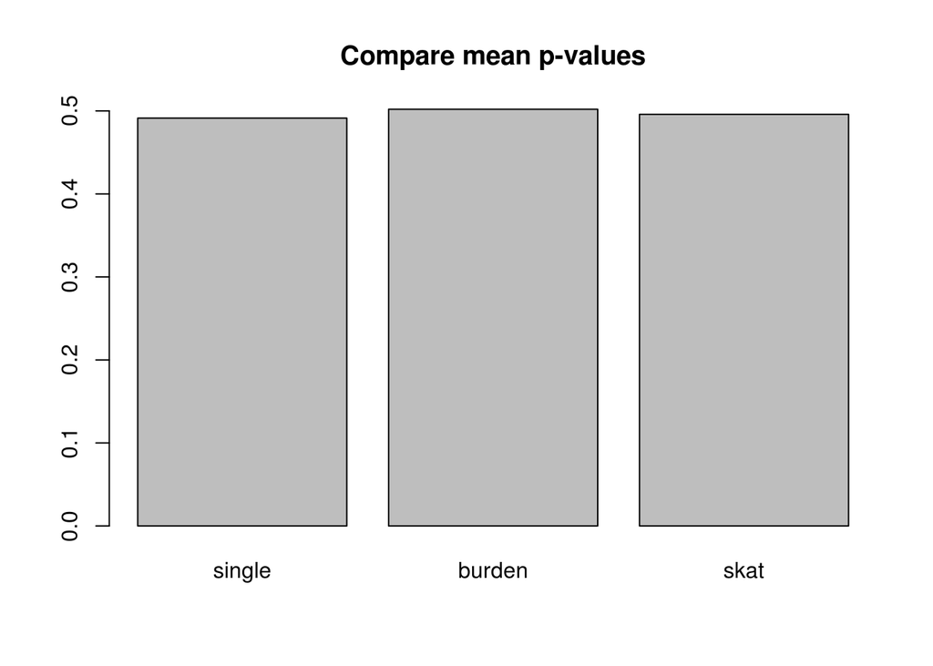

```r
# svt vs burden vs skat
mean_p_values <-
  c(mean(result.df$svt_p, na.rm=TRUE),
    mean(result.df$burden_p, na.rm=TRUE),
    mean(result.df$skat_p, na.rm=TRUE))
names(mean_p_values) <- c("single","burden","skat")
barplot(mean_p_values, main="Compare mean p-values")
```

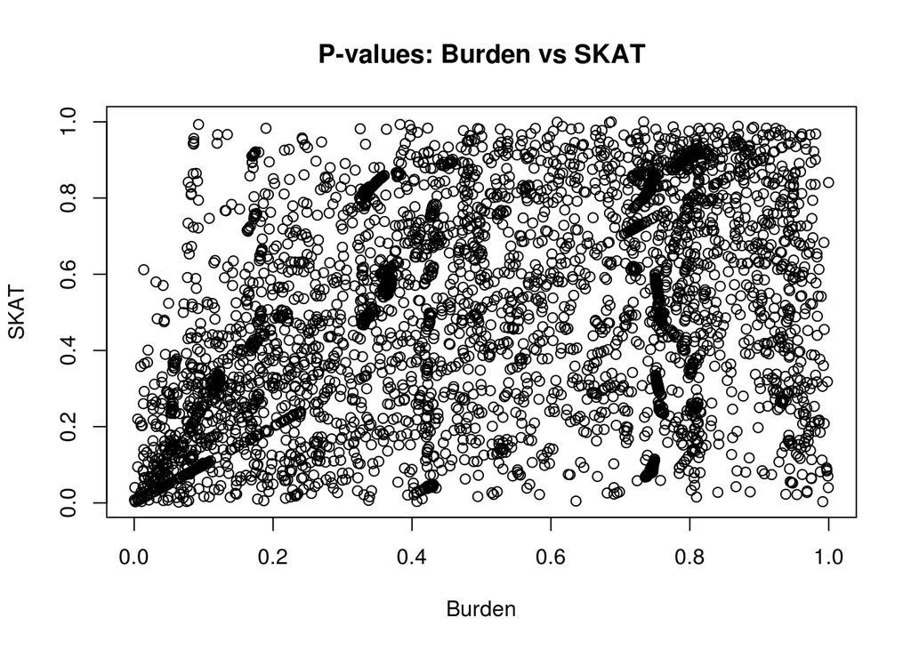

```r
# burden vs skat
plot(result.df$burden_p,
     result.df$skat_p,
     main="P-values: Burden vs SKAT",
     xlab="Burden", ylab="SKAT")
```

```r
cor.test(result.df$burden_p,
         result.df$skat_p)
```

```
##
##  Pearson's product-moment correlation
##
## data:  result.df$burden_p and result.df$skat_p
## t = 24.959, df = 4419, p-value < 2.2e-16
## alternative hypothesis: true correlation is not equal to 0
## 95 percent confidence interval:
##  0.3253944 0.3770731
## sample estimates:
##       cor
## 0.3515015
```

```r
# Clean-up
rm(mean_p_values)
```

# qq_plots

```r
# Remove NAs when not needed for the QQ plots
svt_p <- result.df$svt_p[!is.na(result.df$svt_p)]
length(svt_p) # 4,688
```

```
## [1] 4688
```

```r
summary(svt_p)
```

```
##     Min.  1st Qu.   Median     Mean  3rd Qu.     Max.
## 0.002847 0.223600 0.613300 0.491300 0.722200 1.000000
```

```r
svt_map <- result.df$svt_map[!is.na(result.df$svt_map)]
length(svt_map)
```

```
## [1] 4688
```

```r
summary(svt_map)
```

```
##     Min.  1st Qu.   Median     Mean  3rd Qu.     Max.
## -1.00000  0.08102  0.21190  0.07403  0.22280  0.24820
```

```r
burden_p <- result.df$burden_p[!is.na(result.df$burden_p)]
length(burden_p) # 4,421
```

```
## [1] 4421
```

```r
summary(burden_p)
```

```
##     Min.  1st Qu.   Median     Mean  3rd Qu.     Max.
## 0.000456 0.250000 0.490300 0.502000 0.752500 0.999800
```

```r
burden_map <- result.df$burden_map[!is.na(result.df$burden_map)]
length(burden_map)
```

```
## [1] 4421
```

```r
summary(burden_map)
```

```
##       Min.    1st Qu.     Median       Mean    3rd Qu.       Max.
## -1.0000000  0.0000003  0.0108500 -0.2015000  0.0583400  0.2482000
```

```r
skat_p <- result.df$skat_p[!is.na(result.df$skat_p)]
length(skat_p)
```

```
## [1] 4421
```

```r
summary(skat_p)
```

```
##     Min.  1st Qu.   Median     Mean  3rd Qu.     Max.
## 0.001835 0.252700 0.494300 0.495900 0.763500 1.000000
```

```r
skat_map <- result.df$skat_map[!is.na(result.df$skat_map)]
length(skat_map)
```

```
## [1] 4421
```

```r
summary(skat_map)
```

```
##       Min.    1st Qu.     Median       Mean    3rd Qu.       Max.
## -1.0000000  0.0000002  0.0084970 -0.2053000  0.0534000  0.2482000
```

```r
# Combine svt with burden/skat
svt_burden_p <- ifelse(is.na(result.df$svt_p), result.df$burden_p, result.df$svt_p)
sum(is.na(svt_burden_p))
```

```
## [1] 0
```

```r
length(svt_burden_p)
```

```
## [1] 9109
```

```r
svt_burden_map <- ifelse(is.na(result.df$svt_map), result.df$burden_map, result.df$svt_map)
sum(is.na(svt_burden_map))
```

```
## [1] 0
```

```r
length(svt_burden_map)
```

```
## [1] 9109
```

```r
svt_skat_p <- ifelse(is.na(result.df$svt_p), result.df$skat_p, result.df$svt_p)
sum(is.na(svt_skat_p))
```

```
## [1] 0
```

```r
length(svt_skat_p)
```

```
## [1] 9109
```

```r
svt_skat_map <- ifelse(is.na(result.df$svt_map), result.df$skat_map, result.df$svt_map)
sum(is.na(svt_skat_map))
```

```
## [1] 0
```

```r
length(svt_skat_map)
```

```
## [1] 9109
```

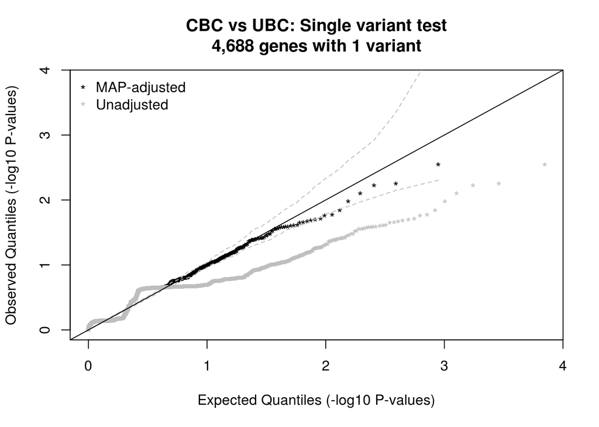

```r
# SKAT-adjusted qq plots (with unadjusted in grey)
QQPlot_Adj(svt_p, svt_map, main="CBC vs UBC: Single variant test\n4,688 genes with 1 variant")
```

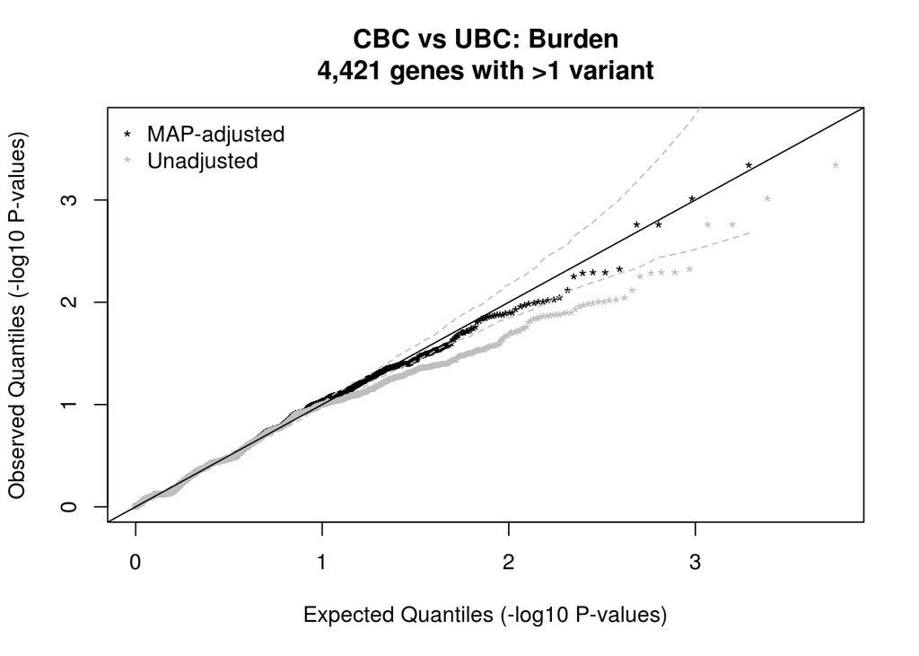

```r
QQPlot_Adj(burden_p, burden_map, main="CBC vs UBC: Burden\n4,421 genes with >1 variant")
```

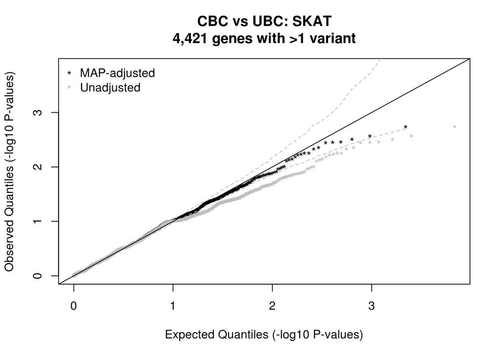

```r
QQPlot_Adj(skat_p, skat_map, main="CBC vs UBC: SKAT\n4,421 genes with >1 variant")
```

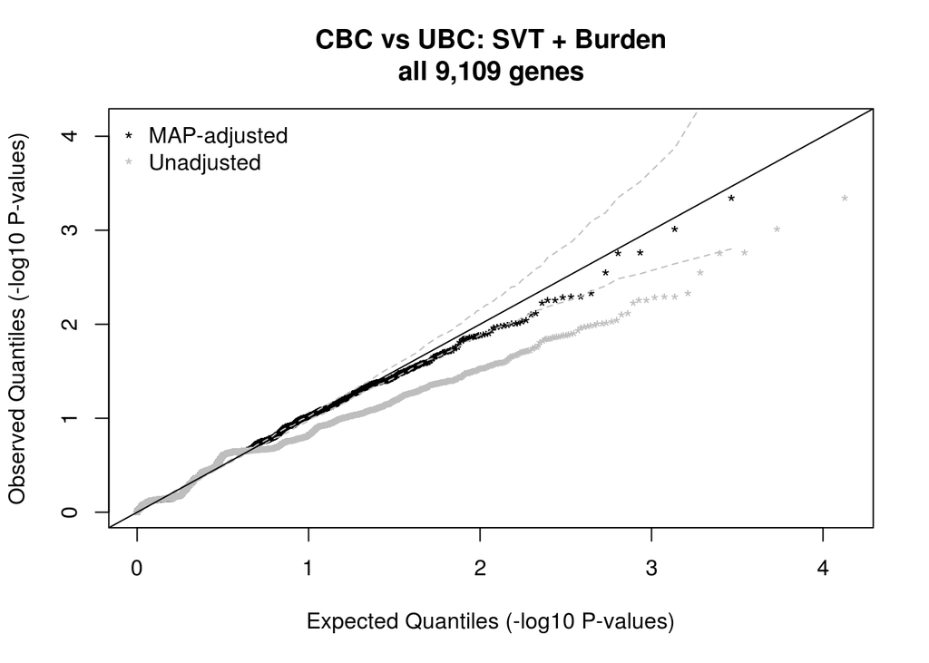

```r
QQPlot_Adj(svt_burden_p, svt_burden_map, main="CBC vs UBC: SVT + Burden\nall 9,109 genes")
```

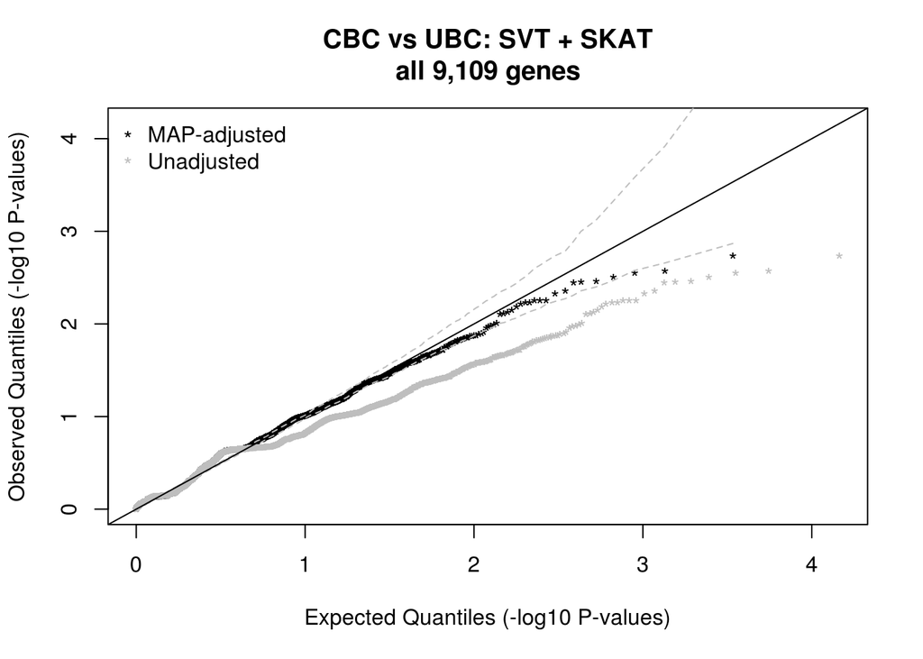

```r
QQPlot_Adj(svt_skat_p, svt_skat_map, main="CBC vs UBC: SVT + SKAT\nall 9,109 genes")
```

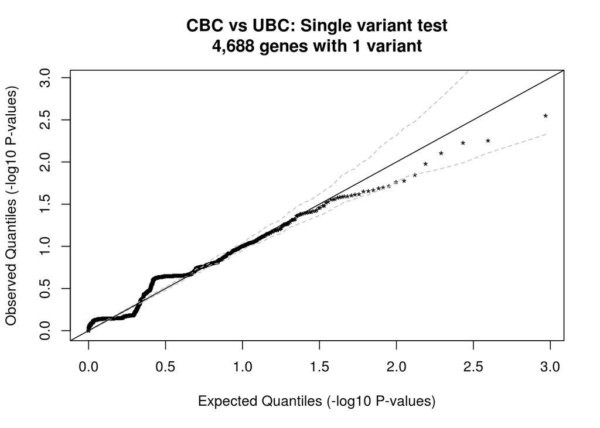

```r
# SKAT-adjusted qq plots (w/o unadjusted)
QQPlot_Adj(svt_p, svt_map, Is.unadjsted=FALSE, main="CBC vs UBC: Single variant test\n4,688 genes with 1 variant")
```

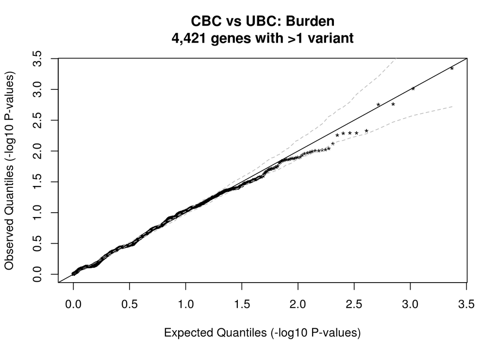

```r
QQPlot_Adj(burden_p, burden_map, Is.unadjsted=FALSE, main="CBC vs UBC: Burden\n4,421 genes with >1 variant")
```

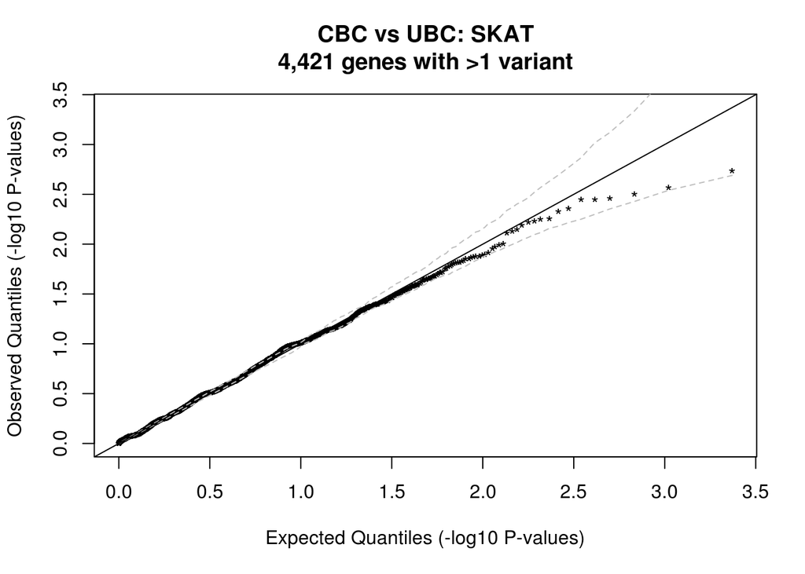

```r
QQPlot_Adj(skat_p, skat_map, Is.unadjsted=FALSE, main="CBC vs UBC: SKAT\n4,421 genes with >1 variant")
```

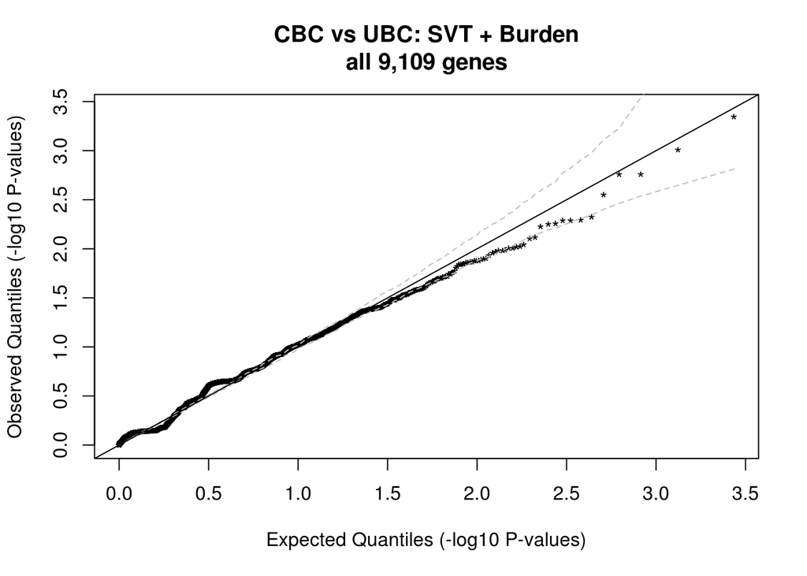

```r
QQPlot_Adj(svt_burden_p, svt_burden_map, Is.unadjsted=FALSE, main="CBC vs UBC: SVT + Burden\nall 9,109 genes")
```

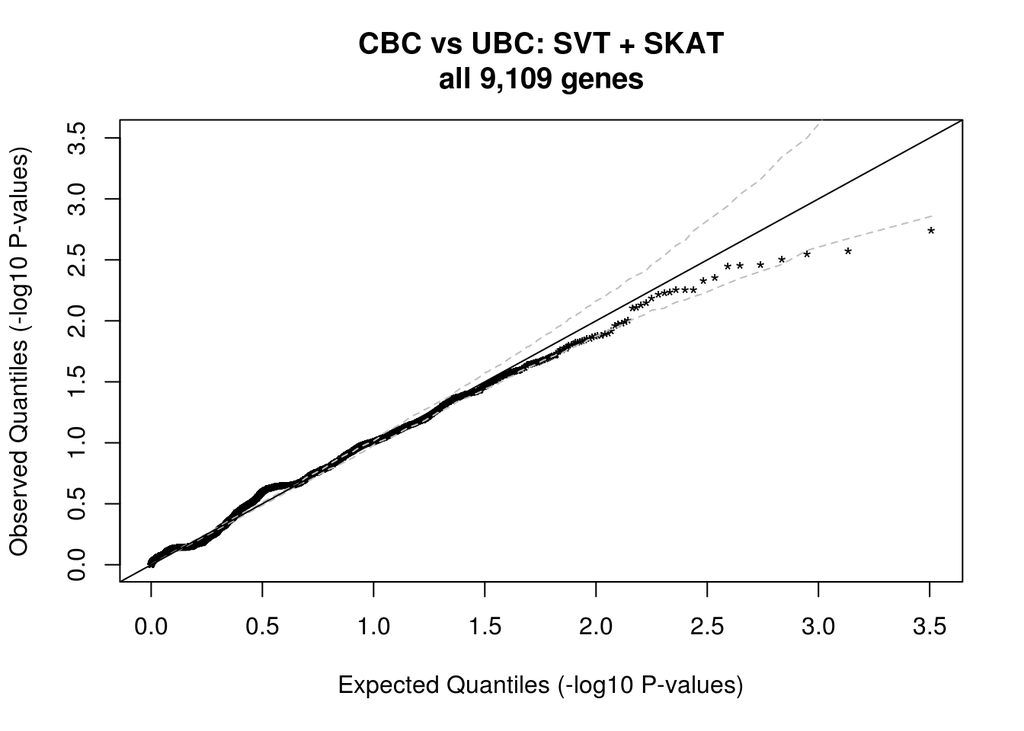

```r
QQPlot_Adj(svt_skat_p, svt_skat_map, Is.unadjsted=FALSE, main="CBC vs UBC: SVT + SKAT\nall 9,109 genes")
```

```r
# --- Look at the genes with >10 aggregated events --- #

selected_genes <- result.df$counts_per_gene >= 10
sum(selected_genes)
```

```
## [1] 2168
```

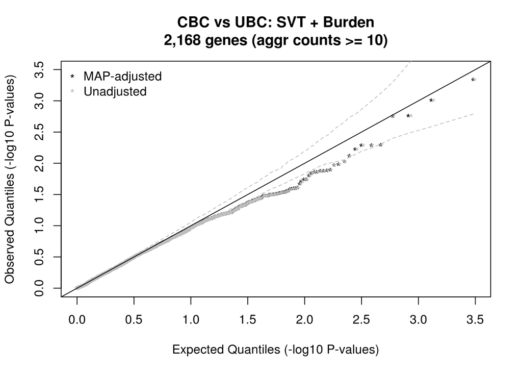

```r
svt_burden_p_selected <- svt_burden_p[selected_genes]
svt_burden_map_selected <- svt_burden_map[selected_genes]

svt_skat_p_selected <- svt_skat_p[selected_genes]
svt_skat_map_selected <- svt_skat_map[selected_genes]

# SKAT-adjusted qq plots (with unadjusted in grey)
QQPlot_Adj(svt_burden_p_selected, svt_burden_map_selected,
           main="CBC vs UBC: SVT + Burden\n2,168 genes (aggr counts >= 10)")
```

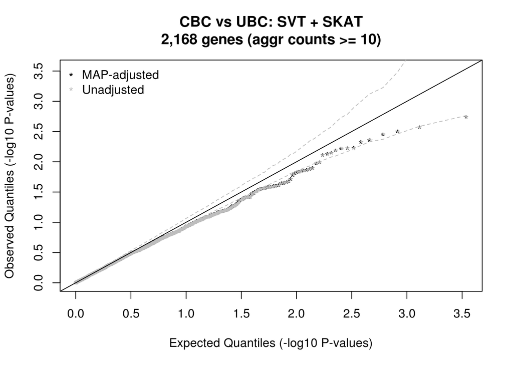

```r
QQPlot_Adj(svt_skat_p_selected, svt_skat_map_selected,
           main="CBC vs UBC: SVT + SKAT\n2,168 genes (aggr counts >= 10)")
```

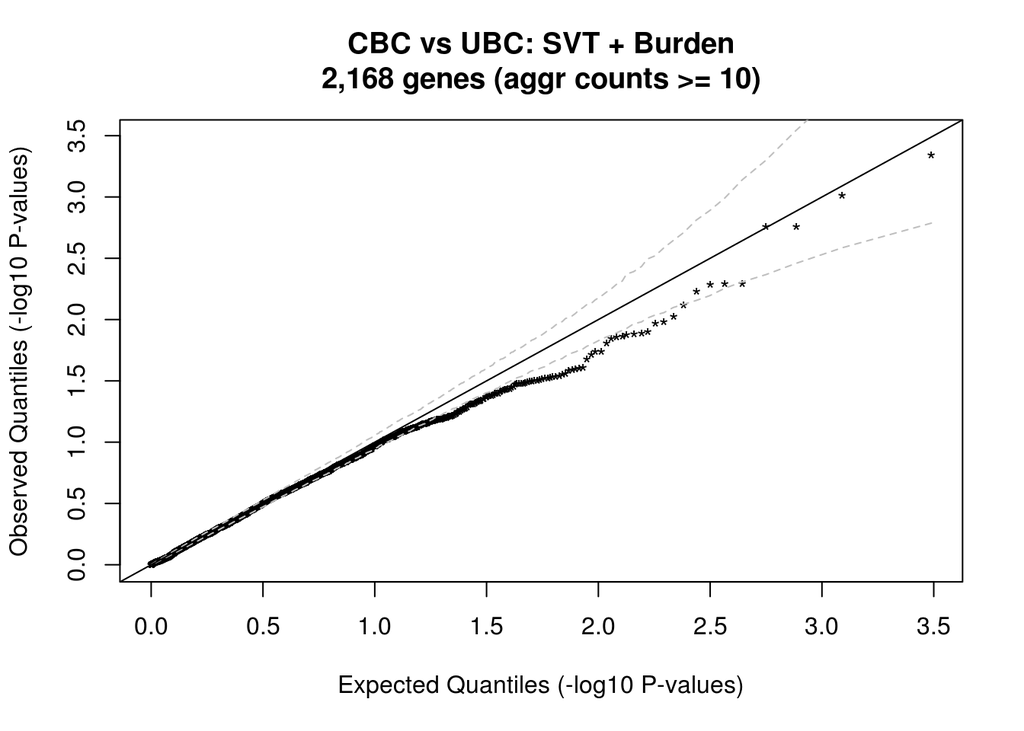

```r
# SKAT-adjusted qq plots (w/o unadjusted)
QQPlot_Adj(svt_burden_p_selected, svt_burden_map_selected, Is.unadjsted=FALSE,
           main="CBC vs UBC: SVT + Burden\n2,168 genes (aggr counts >= 10)")
```

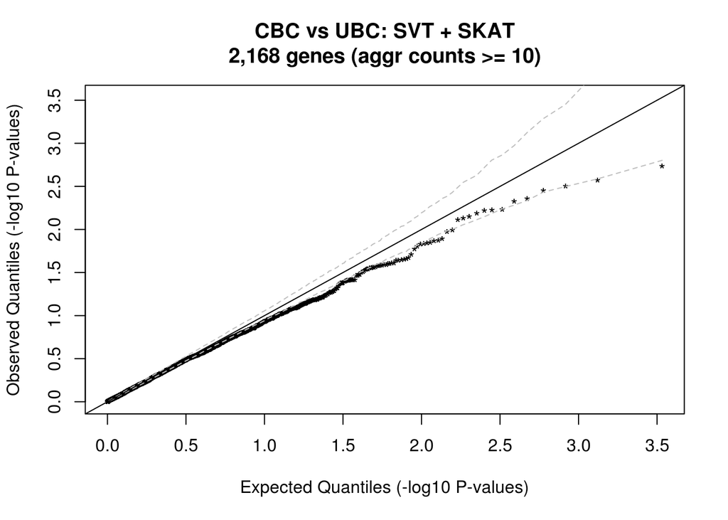

```r
QQPlot_Adj(svt_skat_p_selected, svt_skat_map_selected, Is.unadjsted=FALSE,
           main="CBC vs UBC: SVT + SKAT\n2,168 genes (aggr counts >= 10)")
```

```r
# --- Clean-up --- #

rm(svt_p, svt_map, burden_p, burden_map, skat_p, skat_map,
   svt_burden_p, svt_burden_map, svt_burden_p_selected, svt_burden_map_selected,
   svt_skat_p, svt_skat_map, svt_skat_p_selected, svt_skat_map_selected,
   selected_genes)
```

# data_summary

```r
dim(genotypes.mx)
```

```
## [1] 18551   478
```

```r
class(genotypes.mx)
```

```
## [1] "matrix"
```

```r
genotypes.mx[1:5,1:5]
```

```
##              P1_A01 P1_A02 P1_A03 P1_A04 P1_A05
## Var000000026      0     NA      0      0      0
## Var000000029      0      0      0      0      0
## Var000000031      0      0      0      0      0
## Var000000053      0      0      0      0     NA
## Var000000064      0      0      0      0     NA
```

```r
dim(kgen.df)
```

```
## [1] 18551     9
```

```r
colnames(kgen.df)
```

```
## [1] "SplitVarID"  "kgen.AC"     "kgen.AN"     "kgen.AF"     "kgen.AFR_AF"
## [6] "kgen.AMR_AF" "kgen.EAS_AF" "kgen.EUR_AF" "kgen.SAS_AF"
```

```r
kgen.df[1:5,1:5]
```

```
##                SplitVarID kgen.AC kgen.AN     kgen.AF kgen.AFR_AF
## Var000000026 Var000000026      NA      NA          NA          NA
## Var000000029 Var000000029       1    5008 0.000199681           0
## Var000000031 Var000000031       1    5008 0.000199681           0
## Var000000053 Var000000053      NA      NA          NA          NA
## Var000000064 Var000000064      NA      NA          NA          NA
```

```r
dim(exac.df)
```

```
## [1] 18551    48
```

```r
colnames(exac.df)
```

```
##  [1] "SplitVarID"              "exac_non_TCGA.AF"
##  [3] "exac_non_TCGA.AC"        "exac_non_TCGA.AN"
##  [5] "exac_non_TCGA.AC_FEMALE" "exac_non_TCGA.AN_FEMALE"
##  [7] "exac_non_TCGA.AC_MALE"   "exac_non_TCGA.AN_MALE"
##  [9] "exac_non_TCGA.AC_Adj"    "exac_non_TCGA.AN_Adj"
## [11] "exac_non_TCGA.AC_Hom"    "exac_non_TCGA.AC_Het"
## [13] "exac_non_TCGA.AC_Hemi"   "exac_non_TCGA.AC_AFR"
## [15] "exac_non_TCGA.AN_AFR"    "exac_non_TCGA.Hom_AFR"
## [17] "exac_non_TCGA.Het_AFR"   "exac_non_TCGA.Hemi_AFR"
## [19] "exac_non_TCGA.AC_AMR"    "exac_non_TCGA.AN_AMR"
## [21] "exac_non_TCGA.Hom_AMR"   "exac_non_TCGA.Het_AMR"
## [23] "exac_non_TCGA.Hemi_AMR"  "exac_non_TCGA.AC_EAS"
## [25] "exac_non_TCGA.AN_EAS"    "exac_non_TCGA.Hom_EAS"
## [27] "exac_non_TCGA.Het_EAS"   "exac_non_TCGA.Hemi_EAS"
## [29] "exac_non_TCGA.AC_FIN"    "exac_non_TCGA.AN_FIN"
## [31] "exac_non_TCGA.Hom_FIN"   "exac_non_TCGA.Het_FIN"
## [33] "exac_non_TCGA.Hemi_FIN"  "exac_non_TCGA.AC_NFE"
## [35] "exac_non_TCGA.AN_NFE"    "exac_non_TCGA.Hom_NFE"
## [37] "exac_non_TCGA.Het_NFE"   "exac_non_TCGA.Hemi_NFE"
## [39] "exac_non_TCGA.AC_SAS"    "exac_non_TCGA.AN_SAS"
## [41] "exac_non_TCGA.Hom_SAS"   "exac_non_TCGA.Het_SAS"
## [43] "exac_non_TCGA.Hemi_SAS"  "exac_non_TCGA.AC_OTH"
## [45] "exac_non_TCGA.AN_OTH"    "exac_non_TCGA.Hom_OTH"
## [47] "exac_non_TCGA.Het_OTH"   "exac_non_TCGA.Hemi_OTH"
```

```r
exac.df[1:5,1:5]
```

```
##                SplitVarID exac_non_TCGA.AF exac_non_TCGA.AC
## Var000000026 Var000000026               NA               NA
## Var000000029 Var000000029        1.506e-04               16
## Var000000031 Var000000031        2.354e-04               25
## Var000000053 Var000000053        1.883e-05                2
## Var000000064 Var000000064        9.416e-06                1
##              exac_non_TCGA.AN exac_non_TCGA.AC_FEMALE
## Var000000026               NA                      NA
## Var000000029           106210                       8
## Var000000031           106210                       4
## Var000000053           106210                       0
## Var000000064           106206                       0
```

```r
dim(variants.df)
```

```
## [1] 18551    44
```

```r
str(variants.df)
```

```
## 'data.frame':    18551 obs. of  44 variables:
##  $ SplitVarID        : Factor w/ 343824 levels "Var000000001",..: 26 29 31 53 64 167 227 237 300 400 ...
##  $ SYMBOL            : Factor w/ 19862 levels "A1BG","A1CF",..: 11149 11149 11149 8665 8665 540 540 540 18233 13545 ...
##  $ TYPE              : Factor w/ 2 levels "INDEL","SNP": 2 2 2 2 2 2 2 2 2 2 ...
##  $ CHROM             : Factor w/ 25 levels "1","10","11",..: 1 1 1 1 1 1 1 1 1 1 ...
##  $ POS               : int  881871 883883 883946 897287 897792 979748 987173 989899 1132513 1246373 ...
##  $ REF               : Factor w/ 2142 levels "A","AAAAAAAAAAAAAAAAAAAAAAAG",..: 1044 1575 539 539 539 1 1575 539 539 1044 ...
##  $ ALT               : Factor w/ 1297 levels "A","AAAAAAAAAAAAACT",..: 1 323 989 989 989 989 664 989 989 1 ...
##  $ ac_raw            : int  1 2 1 1 1 53 1 1 2 1 ...
##  $ af_raw            : num  0.000711 0.001555 0.000774 0.000711 0.000722 ...
##  $ an_raw            : int  1406 1286 1292 1406 1386 1416 1420 1414 1320 1400 ...
##  $ Consequence       : Factor w/ 78 levels "3_prime_UTR_variant",..: 66 28 28 28 66 28 28 28 28 28 ...
##  $ SIFT_call         : Factor w/ 4 levels "deleterious",..: NA 1 1 1 NA 1 1 1 1 1 ...
##  $ SIFT_score        : num  NA 0 0.01 0.04 NA 0.01 0 0.02 0.02 0.05 ...
##  $ PolyPhen_call     : Factor w/ 4 levels "benign","possibly_damaging",..: NA 3 3 3 NA 3 3 3 3 3 ...
```

[output cut: 30 more lines]

```r
variants.df[1:5,1:5]
```

```
##                SplitVarID SYMBOL TYPE CHROM    POS
## Var000000026 Var000000026  NOC2L  SNP     1 881871
## Var000000029 Var000000029  NOC2L  SNP     1 883883
## Var000000031 Var000000031  NOC2L  SNP     1 883946
## Var000000053 Var000000053 KLHL17  SNP     1 897287
## Var000000064 Var000000064 KLHL17  SNP     1 897792
```

```r
dim(phenotypes.df)
```

```
## [1] 478  36
```

```r
str(phenotypes.df)
```

```
## 'data.frame':    478 obs. of  36 variables:
##  $ wes_id        : chr  "P1_A01" "P1_A02" "P1_A03" "P1_A04" ...
##  $ gwas_id       : chr  "id203568" "id357807" "id325472" "id304354" ...
##  $ merged_id     : chr  "P1_A01_id203568" "P1_A02_id357807" "P1_A03_id325472" "P1_A04_id304354" ...
##  $ filter        : chr  "pass" "pass" "pass" "pass" ...
##  $ cc            : int  1 1 1 1 1 1 0 1 1 0 ...
##  $ setno         : int  203568 357807 325472 304354 222648 244843 276284 297810 250898 226974 ...
##  $ registry      : Factor w/ 5 levels "de","IA","IR",..: 3 4 2 2 5 4 2 4 4 2 ...
##  $ family_history: int  1 0 1 1 1 1 1 1 1 0 ...
##  $ age_dx        : int  49 35 32 33 44 28 28 38 35 36 ...
##  $ age_ref       : num  58 36 41 34 49 28 32 44 35 38 ...
##  $ rstime        : num  10.17 1.83 9.75 1.59 5.66 ...
##  $ eig1_gwas     : num  -0.00389 -0.00379 -0.01011 -0.01288 -0.01086 ...
##  $ eig2_gwas     : num  0.00266 0.00246 -0.0001 0.00595 0.01157 ...
##  $ eig3_gwas     : num  0.06803 0.05055 -0.00603 0.00747 0.00144 ...
```

[output cut: 22 more lines]

```r
phenotypes.df[1:5,1:5]
```

```
##        wes_id  gwas_id       merged_id filter cc
## P1_A01 P1_A01 id203568 P1_A01_id203568   pass  1
## P1_A02 P1_A02 id357807 P1_A02_id357807   pass  1
## P1_A03 P1_A03 id325472 P1_A03_id325472   pass  1
## P1_A04 P1_A04 id304354 P1_A04_id304354   pass  1
## P1_A05 P1_A05 id222648 P1_A05_id222648   pass  1
```

```r
dim(result.df)
```

```
## [1] 9109   12
```

```r
str(result.df)
```

```
## 'data.frame':    9109 obs. of  12 variables:
##  $ gene              : chr  "NOC2L" "KLHL17" "AGRN" "TTLL10" ...
##  $ num_var           : int  3 2 3 1 1 1 1 1 2 1 ...
##  $ svt_p             : num  NA NA NA 0.348 0.712 ...
##  $ svt_is_accurate   : logi  NA NA NA TRUE TRUE TRUE ...
##  $ svt_map           : num  NA NA NA 0.0941 0.2124 ...
##  $ burden_p          : num  0.534 0.353 0.399 NA NA ...
##  $ burden_is_accurate: logi  TRUE TRUE TRUE NA NA NA ...
##  $ burden_map        : num  0.0164 0.1005 -1 NA NA ...
##  $ skat_p            : num  0.461 0.848 0.368 NA NA ...
##  $ skat_is_accurate  : logi  TRUE TRUE TRUE NA NA NA ...
##  $ skat_map          : num  0.0137 0.1005 -1 NA NA ...
##  $ counts_per_gene   : num  4 2 36 2 1 1 1 41 3 1 ...
```

```r
result.df[1:5,1:5]
```

```
##          gene num_var     svt_p svt_is_accurate    svt_map
## NOC2L   NOC2L       3        NA              NA         NA
## KLHL17 KLHL17       2        NA              NA         NA
## AGRN     AGRN       3        NA              NA         NA
## TTLL10 TTLL10       1 0.3479001            TRUE 0.09410533
## PUSL1   PUSL1       1 0.7123572            TRUE 0.21235721
```

```r
# Check consistency of rownames and colnames
sum(colnames(genotypes.mx) != rownames(phenotypes.df))
```

```
## [1] 0
```

```r
sum(rownames(genotypes.mx) != rownames(kgen.df))
```

```
## [1] 0
```

```r
sum(rownames(genotypes.mx) != rownames(exac.df))
```

```
## [1] 0
```

```r
sum(rownames(genotypes.mx) != rownames(variants.df))
```

```
## [1] 0
```

# save_results

```r
save.image(paste(results_folder, "r09_SKAT_wecare_only.RData", sep="/"))
```

# final_section

```r
ls()
```

```
## [1] "exac.df"             "genotypes.mx"        "interim_data_folder"
## [4] "kgen.df"             "phenotypes.df"       "result.df"
## [7] "results_folder"      "source_data_folder"  "variants.df"
```

```r
Sys.time()
```

```
## [1] "2017-04-21 00:04:16 BST"
```